# Lines(ggplot2

# With two continuous axes

Sample data used here:

```r
dat <- read.table(header=TRUE, text='
      cond xval yval
   control 11.5 10.8
   control  9.3 12.9
   control  8.0  9.9
   control 11.5 10.1
   control  8.6  8.3
   control  9.9  9.5
   control  8.8  8.7
   control 11.7 10.1
   control  9.7  9.3
   control  9.8 12.0
 treatment 10.4 10.6
 treatment 12.1  8.6
 treatment 11.2 11.0
 treatment 10.0  8.8
 treatment 12.9  9.5
 treatment  9.1 10.0
 treatment 13.4  9.6
 treatment 11.6  9.8
 treatment 11.5  9.8
 treatment 12.0 10.6
')
```

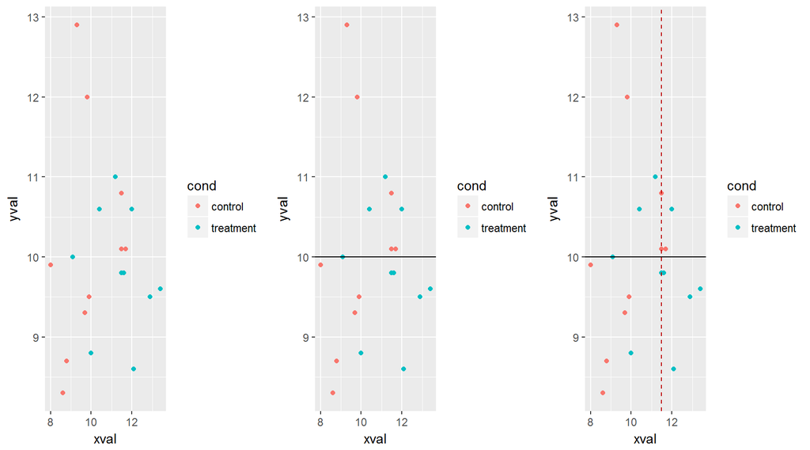

```r
# The basic scatterplot
sp <- ggplot(dat, aes(x=xval, y=yval, colour=cond)) + geom_point()

# Add a horizontal line
hsp <- sp + geom_hline(aes(yintercept=10))

# Add a red dashed vertical line
vsp <- sp + geom_hline(aes(yintercept=10)) +
    geom_vline(aes(xintercept=11.5), colour="#BB0000", linetype="dashed")

grid.arrange(sp, hsp, vsp, ncol=3)
```

## Drawing lines for the mean

It is also possible to compute a mean value for each subset of data, grouped by some variable. The group means would have to be computed and stored in a separate data frame, and the easiest way to do this is to use the dplyr package. Note that the y range of the line is determined by the data.

```r
lines <- dat %>%
  group_by(cond) %>%
  summarise(
    x = mean(xval),
    ymin = min(yval),
    ymax = max(yval)
  )
```

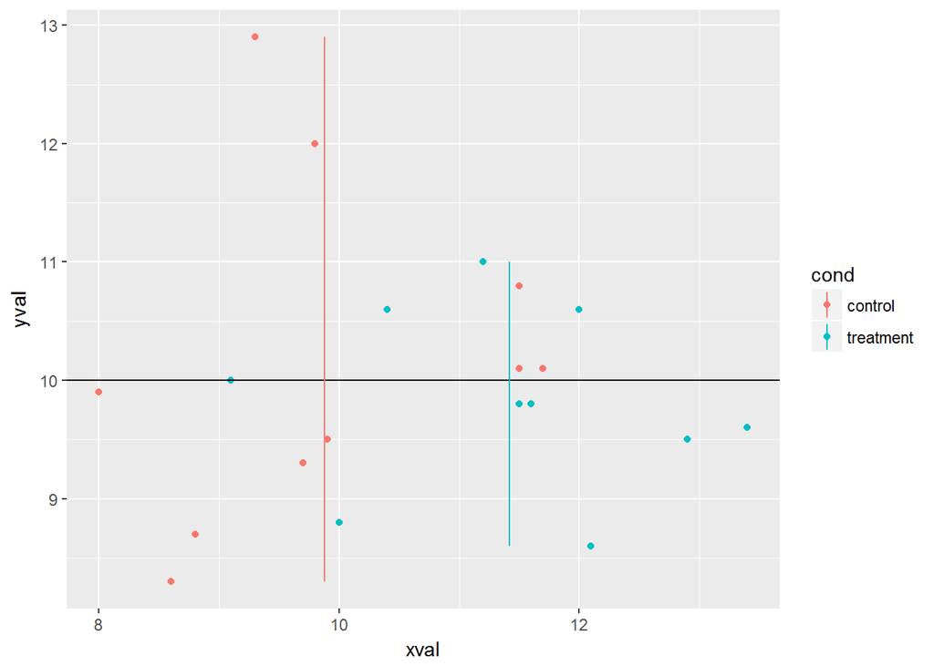

```r
# Add colored lines for the mean xval of each group
# Add colored lines for the mean xval of each group
sp + geom_hline(aes(yintercept=10)) +
     geom_linerange(aes(x=x, y=NULL, ymin=ymin, ymax=ymax), data=lines)
```

## Using lines with facets

Normally, if you add a line, it will appear in all facets.

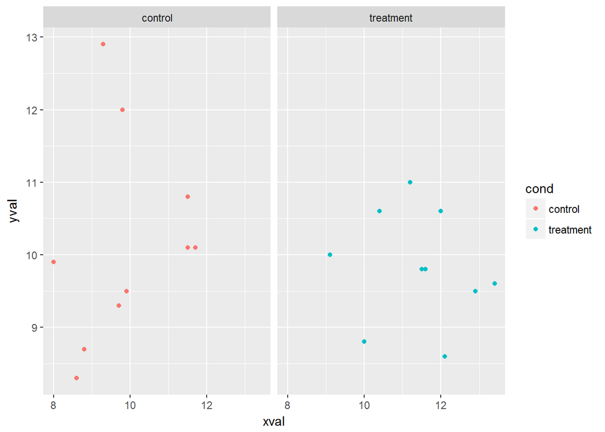

```r
# Facet, based on cond
spf <- sp + facet_grid(. ~ cond)
spf
```

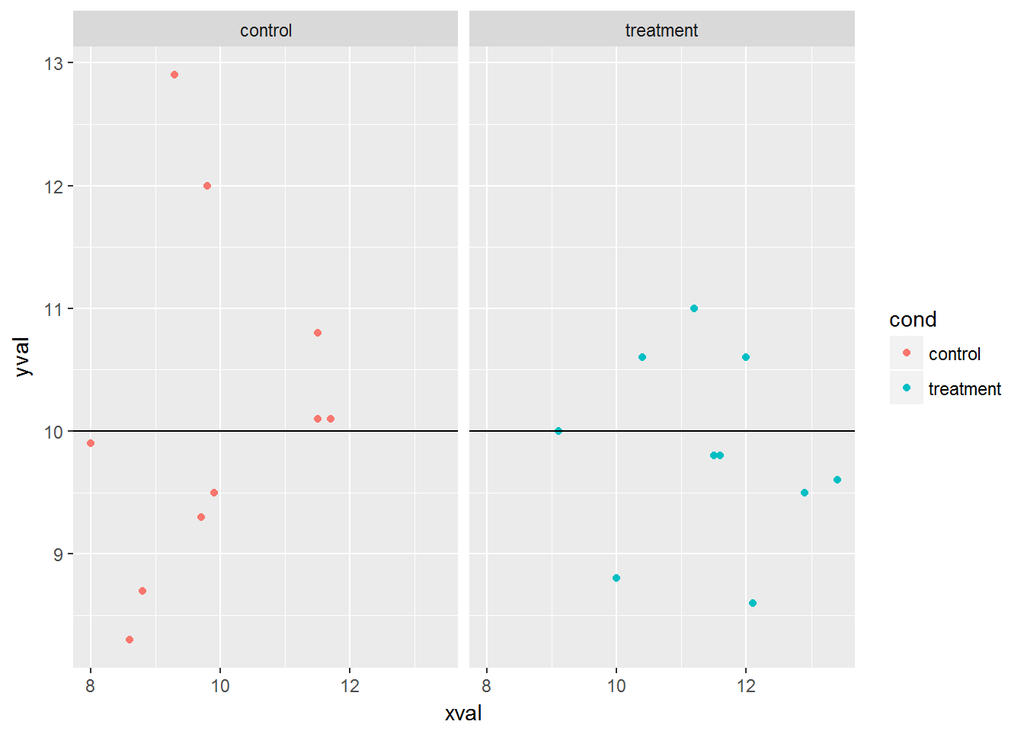

```r
# Draw a horizontal line in all of the facets at the same value
spf + geom_hline(aes(yintercept=10))
```